# The Mobile Web’s Death has been Greatly Exaggerated

2008-04-15

[A recent blog post](http://www.russellbeattie.com/blog/the-end-of-mowser) by Russell Beattie somberly announced the end of his company, [Mowser](http://www.mowser.com/). According to Mowser’s about page, Mowser “mobilizes the web by taking HTML pages normally viewed on a PC and adapts them so they work on a mobile phone.” In his post, Beattie says that “I don’t actually believe in the “Mobile Web” anymore,” and from that, some people have extrapolated that Beattie is proclaiming that the Mobile Web is Dead.

But Read What He’s Actually Saying  
If you read further, and ignore the [provocative headlines](http://www.readwriteweb.com/archives/is_the_mobile_web_dead.php), and understand what Beattie is actually saying, he’s not claiming the Mobile Web is dead at all:  
> “I think anyone currently developing sites using XHTML-MP markup, no Javascript, geared towards cellular connections and two inch screens are simply wasting their time […]“

This is hardly the death of the mobile web (shame on you, [ReadWriteWeb](http://www.readwriteweb.com/)!). All that this means is that the rules of the game have changed.

What “The Mobile Web” Used to Be  
What do people mean when they talk about the Mobile Web? I think the usual context of the question is “how can we get people to look at our content from their mobile device?” In the past, simply presenting one’s content on the mobile web was a challenge. Browser technology was abysmal. CSS and JavaScript were out of the question. “Adapted” sites were developed in the crippled WML markup, or other [proprietary formats](http://en.wikipedia.org/wiki/Imode), which made the browsing experience more reminiscent of using [Gopher](http://en.wikipedia.org/wiki/Gopher_%28protocol%29) than a [real web browser](http://www.operamini.com/). Services like [Mowser](http://www.mowser.com/) and [Skweezer](http://www.skweezer.net/) were created to adapt the existing, vibrant content into low-fi versions for phones.

What “The Mobile Web” Is Today  
What I took away from Russell Beattie’s post was that the need for tools like Mowser and Skweezer have been obviated by advances in mobile browser technology. Does this mean that the mobile web is dead? Of course not! And, as far as I can tell, Beattie wasn’t even claiming that to be the case. Instead, I think the definition of the mobile web is changing.

The internet is comprised of three types of pages (behold my amazing [OmniGraffle](http://www.omnigroup.com/applications/omnigraffle/pro/) skills):

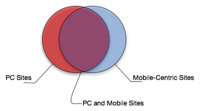

There are sites that are intended for viewing on a stationary computer, and sites that are intended for viewing on a mobile device. There is also a huge overlap of pages that work well for both contexts. This is because the barrier of how to present data on a mobile device, which was initially a barrier, has been mostly overcome.

Examples of using sites in the “purple zone” on a mobile device might be * Wikipedia – looking up a bit of trivia when among friends at a coffee shop (got this one from Tichy on [News.YC](http://news.ycombinator.com/)… thanks, Tichy!) * IMDB – looking up who the did the voice in the Pixar film that you just saw with your kids. * Google Maps – Wandering around in Chicago, and you want to know, what the heck is that building?

It’s perhaps the most difficult to define sites in the “red” PC-Only area. I can think of a few: * Items requiring intensive keyboard work, like [word processing](http://writer.zoho.com/jsp/home.jsp?serviceurl=%2Findex.do) or [blogging](http://www.blogger.com/). * Anything involving heavy graphics, such as online games (and pornographic sites? Perhaps I’m just old-fashioned) * Number-crunching or mathematical modelling and simulations.

Where Does This Leave the Mobile Web?  
So, what is left in the light blue section? It has to do with context. What does someone with a mobile device look at, that a person browsing from a PC or laptop does not? What makes a mobile device unique? Well, duh, it’s mobility!

For years people have been prophecizing the coming of Location Based Services. I think that this area has lots of potential. Companies like [Loopt](https://loopt.com/loopt/sess/index.aspx) have married social services with location awareness to create a compelling product that started out on Boost and Sprint, and it is supposedly coming to other carriers soon. Similarly, [Meetro](http://www.meetro.com/) combines location and Instant Messaging. There are companies who produce audio tours which are location-aware. Fleet management services are exploring the mobile web for business opportunities. It’s not hard to imagine that the next killer app is waiting to be discovered in this space, making our iPhones indispensible. Mobile devices have now advanced to the point where it’s Location-Based Services turn to shine.

The New Mobile Web  
The key is context. What do people need from the web when they’re using a mobile device? What do you think?

[This work is licensed under a [Creative Commons Attribution-NonCommercial-NoDerivatives 4.0 International License](http://creativecommons.org/licenses/by-nc-nd/4.0/) .](http://creativecommons.org/licenses/by-nc-nd/4.0/)